# Visualizing expectations and variation through simulation

P. Adames

2021-09-06

## Expected values and variance

I am not a fan of gambling but I find it interesting to think that life itself is a gamble. To avoid the inevitability of daily random events seems futile: traffic volume and weather are but the two more prominent in our daily lives.

Oftentimes forecasts and averages are rendered useless by the seemingly wild variations encountered in spatial and temporal oddities inherent to natural phenomena. After all, statistics in general is well known for failing to predict the unusual events.

## Wagers

As a means to experiencing the impact of expected values and variability let’s follow a slightly modified example of wagers from (Rodriguez and Mendes 2018, 19).

For wager 3: you pay $300 to enter and I roll a die. If it comes up 1, 2, or 3, then I keep your money. If it comes up 4, 5, or 6, then I give you back $600 (your original bet plus a $300 profit).

For wager 4: you pay $300 to enter and I roll a die. If it comes up 1 or 2 then I get to keep your money. If it comes up 3, 4, 5, or 6 then I give you back $450 (your original $300 plus a profit of $150).

## Comparing the wagers

We need to compare the two wagers to assess their relative benefit. The statistical mean of the expected value of each wager is a  
straightforward way of doing so.

### Expected Profit from the wagers

The profit of a wager is defined as the payout minus the cost of entry. The expected profit of each wager are:

```
E(X)   = [x_1 x P(X=x_1) + .. + x_n P(X=x_n)] - C                                               [1]
       = [(x_1 -C) x P(X=x_1) + .. + (x_n -C) x P(X=x_n)]                                       [2]

E(W_3) = [(0) x (1/2) + 600 x (1/2)] - 300
       = [(-300) x (1/2) + (300) x (1/2)]
       = 0

E(W_4) = [(0) x (1/3) + 450 x (2/3)] - 300
       = [(-300) x (1/3) + 150 x (2/3)]
       = 0
```

The second expression, Eq [2], in the above formulae is simpler to compute the variance in Eq. [3] below.

Note: I modified the values of the original wagers in an effort to make the dollar amounts more realistic. This apparently takes away from what is considere a fair bet, however we will defer that subject for another day and definitively recommend that the curious reader go to the motivating source for this discussion (Rodriguez and Mendes 2018, Chapter 2)

Let’s use R to compute those values.

```r
cost_of_entry = 300
probability_of_die_eq_or_less_than_three = 0.5
payout_of_die_eq_or_less_than_three = 0
payout_of_die_greater_than_three = 300 + 300
expected_value_wager_3 <- (payout_of_die_eq_or_less_than_three *
                          probability_of_die_eq_or_less_than_three +
                          payout_of_die_greater_than_three * (1 - probability_of_die_eq_or_less_than_three)) -
  cost_of_entry
cat(paste(
  paste("Expected net profit from wager 3:",
        ifelse(all.equal(expected_value_wager_3, 0.0),
               0.0,
               expected_value_wager_3),
        sep = "\n"),
  " dollars"))
```

```
## Expected net profit from wager 3:
## 0  dollars
```

In a similar fashion the expected statistical profit for wager 4 is:

```r
cost_of_entry = 300
probability_of_die_eq_or_less_than_two = 1 / 3
payout_of_die_eq_or_less_than_two = 0
payout_of_die_greater_than_two = 300 + 150
expected_value_wager_4 <- (payout_of_die_eq_or_less_than_two * probability_of_die_eq_or_less_than_two +
                             payout_of_die_greater_than_two * (1 - probability_of_die_eq_or_less_than_two)) -
                             cost_of_entry
cat(paste(
  paste("Expected net profit from wager 4:",
        ifelse(all.equal(expected_value_wager_4, 0),
               0,
               expected_value_wager_3),
        sep = "\n"),
  " dollars"))
```

```
## Expected net profit from wager 4:
## 0  dollars
```

All that effort to confirm that neither wager will either make you money nor will make you lose a penny in the long run. So, where does that leave us in terms of the relative merits or drawbacks if each bet? We need other tools to analyze the outcomes from engaging in either wager.

The first thing we will look at is a verification that the expected value does manifest in reality, albeit after a few repetitions, after all practice makes perfect, right?

### Simulation

In the following animated gif image you will see 30 sets of 20,000 bets using wager 3 in blue and the same number of bets using wager 4 in red. Each of the 30 sets starts with a different random number seed before sampling the die with replacement 20,000 times. Because R is a vectorized language, this is done in a single line:

```
die_results = sample(x =1:6, size = 20000, replace = TRUE)
```

The running profit is obtained by dividing the sum of the net profit by the number of times played. That explains why if you always *won* the bet the maximum the running profit would ever be is the maximum payout, `$300` in the case of wager 3 and `$150` for wager 4. However, if you always *lost* both would averge a $300 loss. Please remember that this does not make wager 3 any more desirable by itself because both converge to the same expected value in the long term, zero profit.

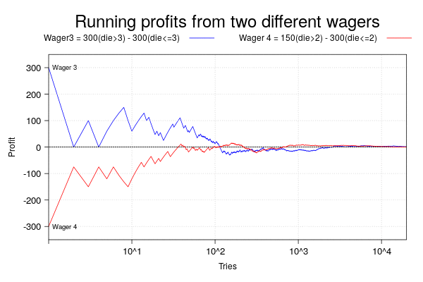

## Variance

So, how else can we qualify the different wagers? Are they different in any practical way?

The statistical variance might give us a clue, it is calculated as follows:

```
V(x) = E{[X - E(X)]^2}                                                       [3]
     = E{X^2 - 2 X E(X) + {E(X)}^2
     = E(X^2) - 2 E(X) E(X) + {E(X)}^2
     = E(X^2) - {E(X)}^2
     = (x_1)^2 P(X = x_1) + .. + (x_n)^2 P(X = x_n)
       - {x_1 P(X = x_1) + .. + x_n P(X= x_n)}^2                                                [4]
```

Substituting for wager 3:

```
V(W_3) = [(-300)^2 x (1/2) + (300)^2 x (1/2)] - {(-300) x (1/2) + 300 x (1/2)}^2
       =  300^2 - {0}
       =  90,000

V(W_4) = [(-300)^2 x (1/3) + (150)^2 x (2/3)] - {(-300) x (1/3) + (150) x (2/3)}^2
       =  30,000 + 50 x 150 x 2 - {0}
       = 30,000 + 15,000
       = 45,000
```

This means that the variability of the profit with wager 3 can be substantially larger that with wager 4, although both have zero expected profit in the long run. What does that say about the gambling budget necessary to sustain these wagers?

## Experiencing variability via simulation

The following animated image shows 60 such sets of 2,000 bets one for each wager. The idea is to glance at all of them to get a sense for the wager that gives the most extreme variations in the positive or negative cash flow necessary to sustain the 2,000 bets.

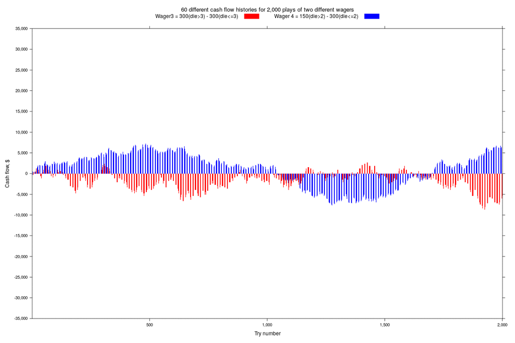

Overall, it seems the red histograms span larger areas than the blue ones. This reinforces the results from the calculation of variance showing that wager 3 has more variability than wager 4.

Note that wager 3 may require larger amounts of cash to sustain the 2,000 bets, when the cash flow is negative. At this point is worth reminding the reader that both wagers have a neutral expected profit.

## References

Rodriguez, Abel, and Bruno Mendes. 2018. *Probability, Decisions and Games: A Gentle Introduction Using r*.